# Chapter 2

*Describe the work you have done this week and summarize your learning.*

- Describe your work and results clearly.
- Assume the reader has an introductory course level understanding of writing and reading R code as well as statistical methods.
- Assume the reader has no previous knowledge of your data or the more advanced methods you are using.

```r
date()
```

```
## [1] "Tue Nov 16 12:38:57 2021"
```

```r
#reading the wrangled data

learning2014_2 <- read.csv("learning2014.csv", header = TRUE, sep = ",", quote = "\"", dec = ".", fill = TRUE, comment.char = "")

#structure of the data
str(learning2014_2)
```

```
## 'data.frame':    166 obs. of  8 variables:
##  $ X       : int  1 2 3 4 5 6 7 8 9 10 ...
##  $ gender  : chr  "F" "M" "F" "M" ...
##  $ Age     : int  53 55 49 53 49 38 50 37 37 42 ...
##  $ Attitude: int  37 31 25 35 37 38 35 29 38 21 ...
##  $ deep    : num  3.58 2.92 3.5 3.5 3.67 ...
##  $ stra    : num  3.38 2.75 3.62 3.12 3.62 ...
##  $ surf    : num  2.58 3.17 2.25 2.25 2.83 ...
##  $ Points  : int  25 12 24 10 22 21 21 31 24 26 ...
```

```r
dim(learning2014_2)
```

```
## [1] 166   8
```

The aim of the study is to examine, how different learning strategies affect students' performance in the final exam of the course. Also connection of the background variables and different learning strategies are studied. This data was collected from a introductory course to statistcs in 2014 for educational purposes.

```r
#summaries and graphs of the data

summary(learning2014_2)
```

```
##        X             gender               Age           Attitude
##  Min.   :  1.00   Length:166         Min.   :17.00   Min.   :14.00
##  1st Qu.: 42.25   Class :character   1st Qu.:21.00   1st Qu.:26.00
##  Median : 83.50   Mode  :character   Median :22.00   Median :32.00
##  Mean   : 83.50                      Mean   :25.51   Mean   :31.43
##  3rd Qu.:124.75                      3rd Qu.:27.00   3rd Qu.:37.00
##  Max.   :166.00                      Max.   :55.00   Max.   :50.00
##       deep            stra            surf           Points
##  Min.   :1.583   Min.   :1.250   Min.   :1.583   Min.   : 7.00
##  1st Qu.:3.333   1st Qu.:2.625   1st Qu.:2.417   1st Qu.:19.00
##  Median :3.667   Median :3.188   Median :2.833   Median :23.00
##  Mean   :3.680   Mean   :3.121   Mean   :2.787   Mean   :22.72
##  3rd Qu.:4.083   3rd Qu.:3.625   3rd Qu.:3.167   3rd Qu.:27.75
##  Max.   :4.917   Max.   :5.000   Max.   :4.333   Max.   :33.00
```

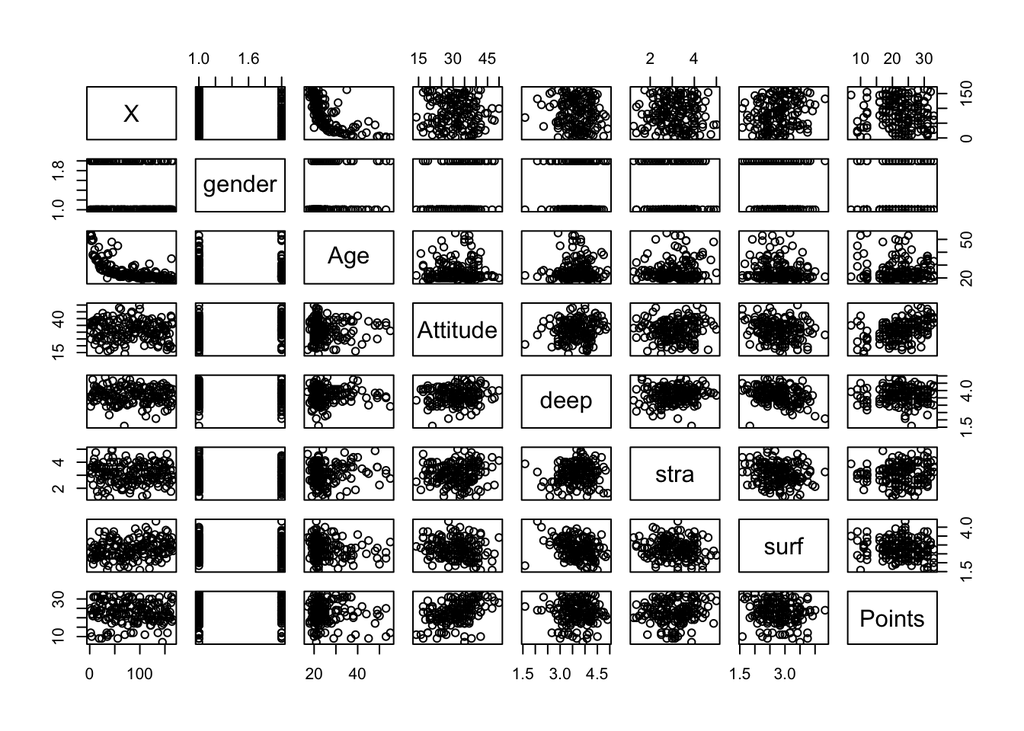

```r
plot(learning2014_2)

library(ggplot2)
```

[figure not shown]

```r
p1 <- ggplot(learning2014_2, aes(x = Attitude, y = Points))
p1
```

[figure not shown]

```r
deep <- learning2014_2$deep
Points <- learning2014_2$Points

p2 <- ggplot(learning2014_2, aes(x = deep, y = Points))
p2
```

```r
#I need to use the old version of R with computer I am still using for couple of days and as far as I'm conserned it does not support all of the graphs, that's why it looks corrupted. But you understand the idea. Also, I'm changing my computer soon, so these problems should be history by the next week!
```

Note: I round up all the values (except for learning strategies) to the closest whole number, to make this more nice to read. Age varies between 17 and 55 in the course. Mean age is 26 and median is 22. Attitude varies between 14 and 50. Mean is 31 and median is 32. Points vary between 7 and 33, 0 points are excluded from the data set. Median and mean are both 23. Learning strategies vary between 1.25 and 5.00. Deep learning has the highest mean, 3.680, and median, 3.667.

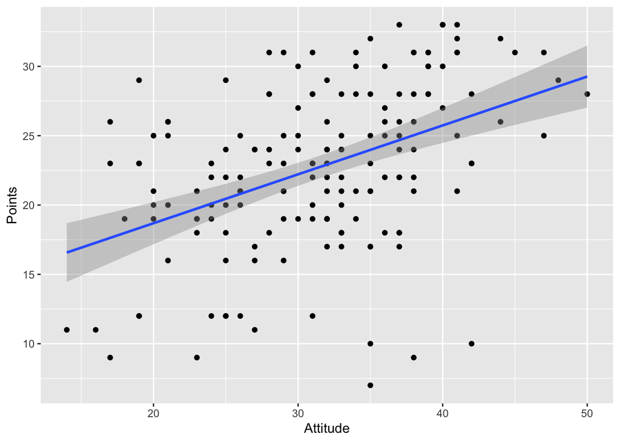

```r
#testing simple regression first

library(ggplot2)
qplot(Attitude, Points, data = learning2014_2) + geom_smooth(method = "lm")
```

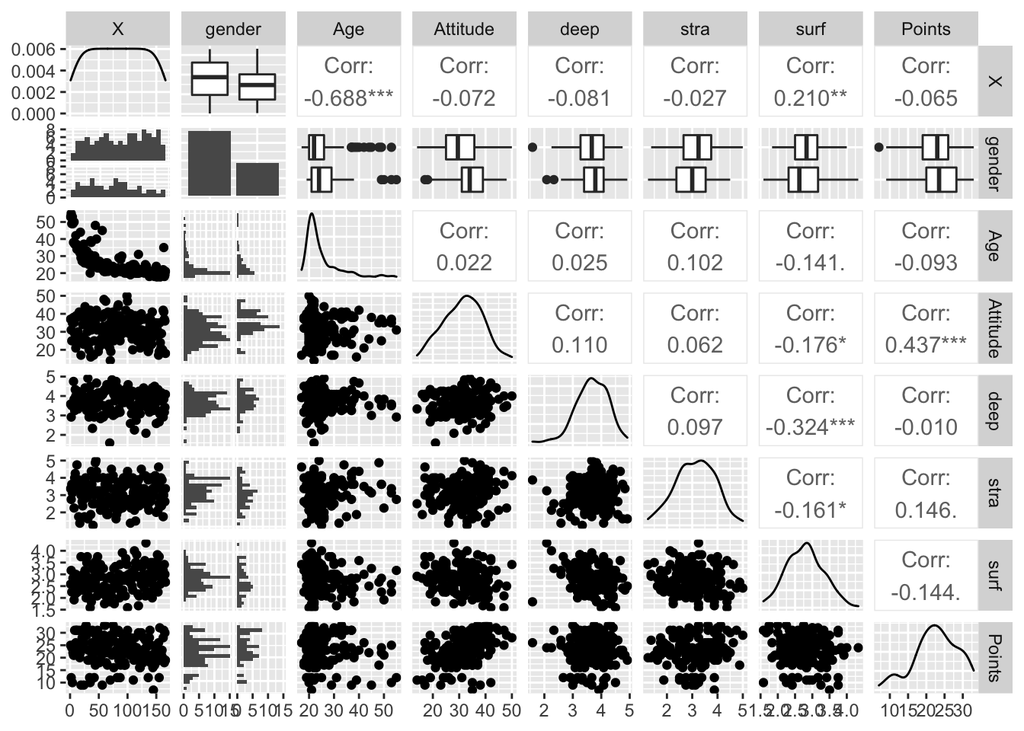

```r
#Multiple regression: Dependent variable = Points, Explanatory variables = Attitude, deep, stra

library(ggplot2)
library(GGally)
ggpairs(learning2014_2, lower = list(combo = wrap("facethist", bins = 20)))
```

```r
my_regression_model1 <- lm(Points ~ Attitude + deep + stra, data = learning2014_2)

my_regression_model1
```

```
##
## Call:
## lm(formula = Points ~ Attitude + deep + stra, data = learning2014_2)
##
## Coefficients:
## (Intercept)     Attitude         deep         stra
##     11.3915       0.3525      -0.7492       0.9621
```

```r
summary(my_regression_model1)
```

```
##
## Call:
## lm(formula = Points ~ Attitude + deep + stra, data = learning2014_2)
##
## Residuals:
##      Min       1Q   Median       3Q      Max
## -17.5239  -3.4276   0.5474   3.8220  11.5112
##
## Coefficients:
##             Estimate Std. Error t value Pr(>|t|)
## (Intercept) 11.39145    3.40775   3.343  0.00103 **
## Attitude     0.35254    0.05683   6.203 4.44e-09 ***
## deep        -0.74920    0.75066  -0.998  0.31974
## stra         0.96208    0.53668   1.793  0.07489 .
## ---
## Signif. codes:  0 '***' 0.001 '**' 0.01 '*' 0.05 '.' 0.1 ' ' 1
##
## Residual standard error: 5.289 on 162 degrees of freedom
## Multiple R-squared:  0.2097, Adjusted R-squared:  0.195
## F-statistic: 14.33 on 3 and 162 DF,  p-value: 2.521e-08
```

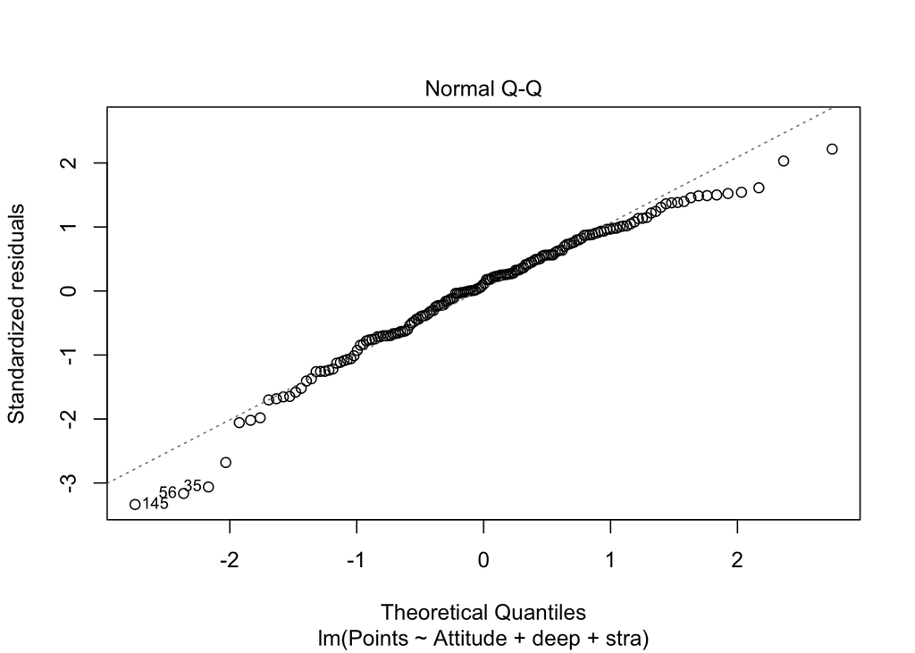

```r
plot(my_regression_model1, which=2)
```

```r
# fit a linear model

my_regression_model1 <- lm(Points ~ 1, Attitude + deep + stra, data = learning2014_2)
my_regression_model1
```

```
##
## Call:
## lm(formula = Points ~ 1, data = learning2014_2, subset = Attitude +
##     deep + stra)
##
## Coefficients:
## (Intercept)
##       21.95
```

```r
summary(my_regression_model1)
```

```
##
## Call:
## lm(formula = Points ~ 1, data = learning2014_2, subset = Attitude +
##     deep + stra)
##
## Residuals:
##     Min      1Q  Median      3Q     Max
## -12.946  -2.946   1.054   6.054  11.054
##
## Coefficients:
##             Estimate Std. Error t value Pr(>|t|)
## (Intercept)  21.9458     0.5356   40.98   <2e-16 ***
## ---
## Signif. codes:  0 '***' 0.001 '**' 0.01 '*' 0.05 '.' 0.1 ' ' 1
##
## Residual standard error: 6.9 on 165 degrees of freedom
```

here's some significanse in the air

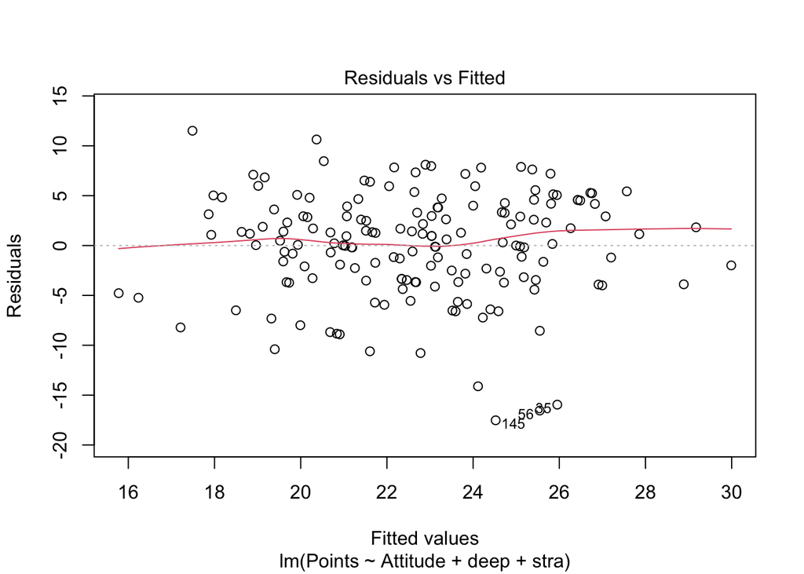

```r
# graphics

library(ggplot2)
library(GGally)

my_regression_model1 <- lm(Points ~ Attitude + deep + stra, data = learning2014_2)

#Residuals vs. fitted values
plot(my_regression_model1, which=1)
```

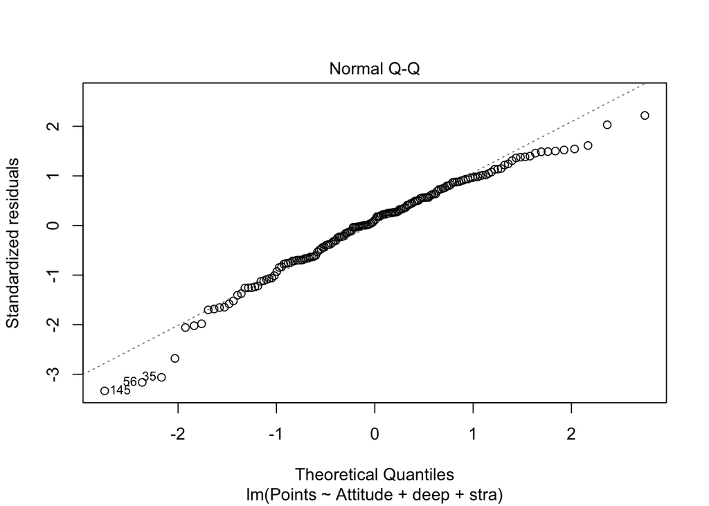

```r
#Normal QQ-plot
plot(my_regression_model1, which=2)
```

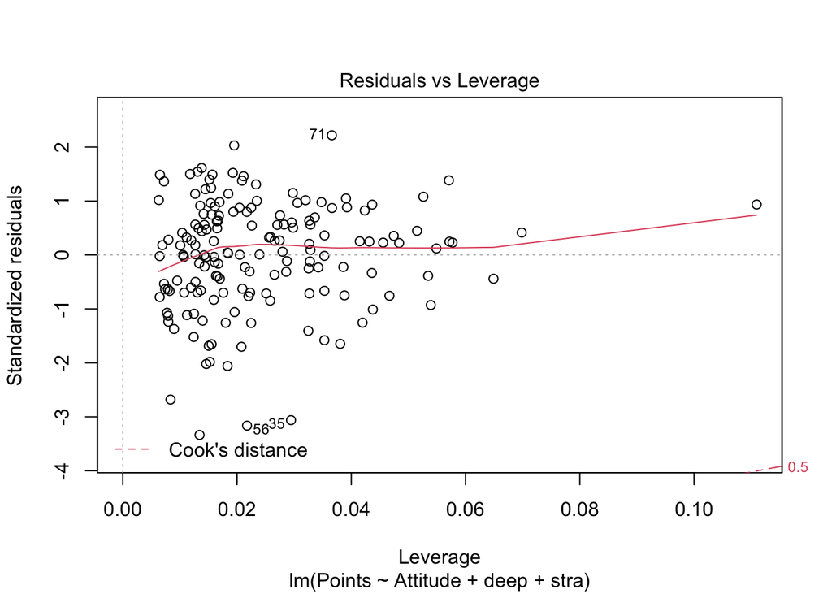

```r
#Residuals vs. leverage
plot(my_regression_model1, which=5)
```